# Klassifikation

Algorithmik und Statistik 1

Sascha Metzger - 1910837830

2019-01-01 (updated: 2020-02-09)

Bitte um Beachtung der [Übungs-Policy](https://weblearn.fh-kufstein.ac.at/mod/page/view.php?id=64482) für genaue Anweisungen und einige Beurteilungsnotizen. Fehler bei der Einhaltung ergeben Punktabzug.

```r
library(statistics4ds)
library(tidyverse)
```

```r
library(plotly)
library(MASS)
library(caret)
library(knitr)
library(kableExtra)
library(e1071)
library(nnet)
library(ellipse)
# helper function to caluculate the rmse for a knn
calc_err = function(actual, predicted) {
  mean(actual != predicted)
}

# import data
weatherAUS = read.csv("data/weatherAUS.csv")

wisc_trn = read.csv("data/wisc-trn.csv")
wisc_tst = read.csv("data/wisc-tst.csv")
```

# Aufgabe 1: Krebserkennung mit KNN [3 Punkte]

Für diese Übung werden wir Daten aus `wisc-trn.csv` und `wisc-tst.csv` verwenden, die jeweils Zug- und Testdaten enthalten. Dies ist eine Modifikation des Brustkrebs-Wisconsin-(Diagnose-)Datensatzes aus dem UCI Machine Learning Repository. Es wurden nur die ersten 10 Merkmalsvariablen bereitgestellt.

- UCI
- [Data Detail](https://archive.ics.uci.edu/ml/machine-learning-databases/breast-cancer-wisconsin/wdbc.names)

Sie sollten erwägen, die Antwort als Faktorvariable zu erzwingen.

Betrachten Sie zwei verschiedene Vorverarbeitungs-Setups:

- **Setup 1**
  - Numerische Variablen nicht skaliert.
- **Setup 2**
  - Numerische Variablen werden auf den Mittelwert 0 und die Standardabweichung 1 skaliert.

Für jeden Aufbau sind KNN-Modelle mit Werten von `k` von `1` bis `200` zu trainieren. Dabei werden nur die Variablen `Radius`, `Symmetrie` und `Textur` verwendet. Berechnen Sie für jede dieser Größen den Klassifizierungsfehler der Prüfung. Diese Ergebnisse sind in einer einzigen Darstellung zusammenzufassen, die den Prüffehler als Funktion von `k` darstellt. (Die Darstellung hat zwei “Kurven”, eine für jeden Aufbau.) Ihre Darstellung sollte visuell ansprechend und gut beschriftet sein und eine Legende enthalten.

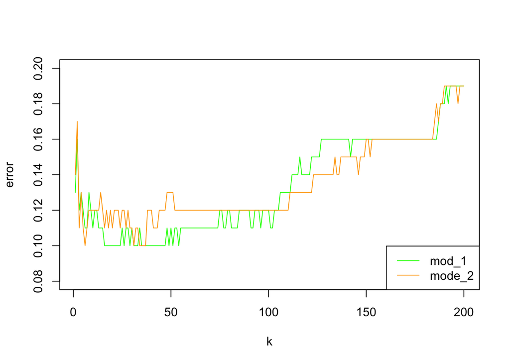

```r
# seed
set.seed(1910837830)

wisc_trn$class = as.factor(wisc_trn$class)
wisc_tst$class = as.factor(wisc_tst$class)

# k
k <- 1:200

# define model setups
wisc_knn_form_1 = as.formula(class ~ radius + symmetry + texture)
wisc_knn_form_2 = as.formula(class ~ scale(radius) + scale(symmetry) + scale(texture))

# get 200 different modules (from 1 to 200)
mod_1 = lapply(k, function(x) {knn3(wisc_knn_form_1, data = wisc_trn, k = x)})
mod_2 = lapply(k, function(x) {knn3(wisc_knn_form_2, data = wisc_trn, k = x)})
# get the predictions from each of our models
pred_1 = lapply(mod_1, predict, newdata = wisc_tst, type = "class")
pred_2 = lapply(mod_2, predict, newdata = wisc_tst, type = "class")
# calculate the errors for all 200 predictions
err_1 = sapply(pred_1, calc_err, actual = wisc_tst$class)
err_2 = sapply(pred_2, calc_err, actual = wisc_tst$class)

plot(k, err_1, type = "l", col = "green", xlab = "k", ylab = "error", ylim = c(0.08, 0.2))
lines(k, err_2, col = "orange")
legend("bottomright", c("mod_1", "mode_2"), lty = c(1, 1), col = c("green", "orange"))
```